# E2Q3 v2

Question 3

```python
# Importing libraries
import pandas as pd
from numpy import *
import matplotlib.pyplot as plt
import numpy as np
import plotly.express as plotx
```

```python
#Initialize random number generator
random.seed(1)
#create array of values from 100 to 200 with a step of 500.
#These values will determine the number of MC simulations.
runs = np.arange (100,200000, 500)
```

Question 3(i):

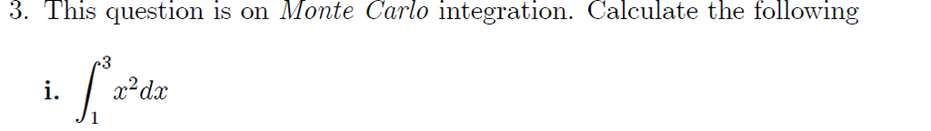

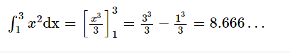

```python
#Question 3(i)
b= 3
a= 1
c =b-a
#Exact solution
Exct3i= (1/3*(b**3)-(1/3*a))

sim_runs=[]; sim_result=[];closed_form =[]; price_diff=[]
for i in range(len(runs)):
    randset = pd.DataFrame(random.rand(runs[i]))


    # MC Integral I = (b-a)* Expected [ f(U x (b-a) +a)]
    I3i =  c*(np.average((randset*c+a)**2))


    # Modulus of Relative Difference
    diff = np.absolute(I3i/Exct3i-1)

    #Appending data into list
    sim_runs.append(runs[i])
    closed_form.append(Exct3i)
    sim_result.append(I3i)
    price_diff.append(diff)


Agg_df = pd.DataFrame({
    'Simulated runs':sim_runs, 'Closed-Form Solution': closed_form,
    'Simulated result': sim_result, 'Relative Diff between MC and Closed-Form': price_diff})

Agg_df
```

|  | Simulated runs | Closed-Form Solution | Simulated result | Relative Diff between MC and Closed-Form |
| --- | --- | --- | --- | --- |
| 0 | 100 | 8.666667 | 8.469021 | 0.022805 |
| 1 | 600 | 8.666667 | 8.762749 | 0.011086 |
| 2 | 1100 | 8.666667 | 8.861966 | 0.022535 |
| 3 | 1600 | 8.666667 | 8.552601 | 0.013161 |
| 4 | 2100 | 8.666667 | 8.651489 | 0.001751 |
| ... | ... | ... | ... | ... |
| 395 | 197600 | 8.666667 | 8.658590 | 0.000932 |
| 396 | 198100 | 8.666667 | 8.644614 | 0.002545 |
| 397 | 198600 | 8.666667 | 8.671380 | 0.000544 |
| 398 | 199100 | 8.666667 | 8.672794 | 0.000707 |
| 399 | 199600 | 8.666667 | 8.671480 | 0.000555 |

400 rows × 4 columns

```python
fig = plotx.scatter(
    Agg_df, x='Simulated runs', y='Relative Diff between MC and Closed-Form',
    title="Relative Diff of MC-Closed-Form result vs Simulated runs"
     ).update_traces(mode='markers', marker=dict(symbol='circle-dot'))
fig.show()
```

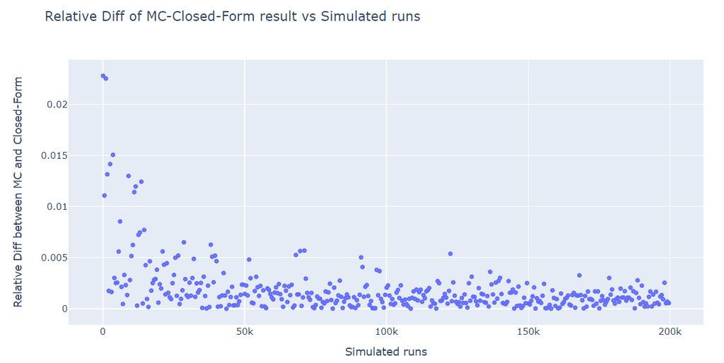

Observation for 3(i):

With reference to the chart above, relative difference of >1% is no longer observable after midway between 0-50k simulations.

Relative differences of <0.5% were only observable after 150k simulations, though there were few remote instances that the difference was close to the 0.5% threshold. Further testing may be required to discover the optimum number of simulation to gain assurance that the relative differences will consistently remain beneath the 0.5% threshold.

No additional simulations were conducted out of consideration for practicality and performance.

Question 3(ii):

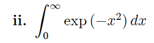

Derivation for Exact Solution:

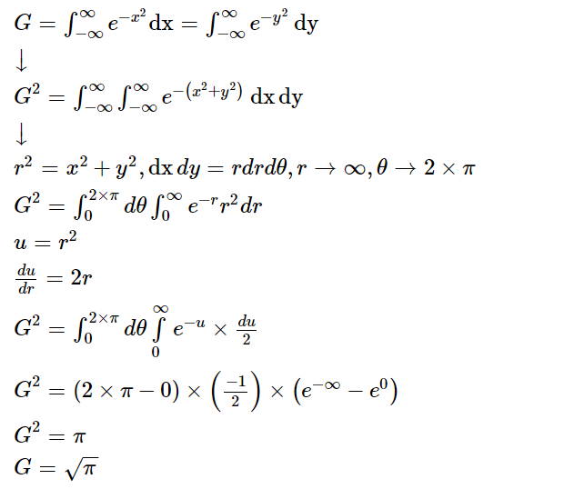

```python
#Question 3(ii)

#Gaussian Integral
Exct3ii = ((np.pi)**0.5)/2

sim_runs2=[]; sim_result2=[];closed_form2 =[]; price_diff2=[]

for i in range(len(runs)):
    randsetii = pd.DataFrame(random.rand(runs[i]))

    # (-1+1/U)**2
    nu_xii = (-1+1/randsetii)**2

    #g(nu_x)/(U*U)
    gii= np.exp(-nu_xii)/(randsetii*randsetii)

    # Expected [ g(nu_x)/(U*U)]
    I3ii =  average(gii)

    # Modulus of Relative Difference
    diff2 = np.absolute(I3ii/Exct3ii-1)

    #Appending data into list
    sim_runs2.append(runs[i])
    closed_form2.append(Exct3ii)
    sim_result2.append(I3ii)
    price_diff2.append(diff2)

Agg_df2 = pd.DataFrame({
    'Simulated runs':sim_runs2, 'Closed-Form Solution': closed_form2,
    'Simulated result': sim_result2, 'Relative Diff between MC and Closed-Form': price_diff2})
Agg_df2
```

|  | Simulated runs | Closed-Form Solution | Simulated result | Relative Diff between MC and Closed-Form |
| --- | --- | --- | --- | --- |
| 0 | 100 | 0.886227 | 0.874923 | 0.012755 |
| 1 | 600 | 0.886227 | 0.920632 | 0.038822 |
| 2 | 1100 | 0.886227 | 0.880459 | 0.006508 |
| 3 | 1600 | 0.886227 | 0.912491 | 0.029636 |
| 4 | 2100 | 0.886227 | 0.867110 | 0.021571 |
| ... | ... | ... | ... | ... |
| 395 | 197600 | 0.886227 | 0.882981 | 0.003663 |
| 396 | 198100 | 0.886227 | 0.888168 | 0.002190 |
| 397 | 198600 | 0.886227 | 0.886462 | 0.000265 |
| 398 | 199100 | 0.886227 | 0.889459 | 0.003647 |
| 399 | 199600 | 0.886227 | 0.885732 | 0.000559 |

400 rows × 4 columns

```python
fig2 = plotx.scatter(
    Agg_df2, x='Simulated runs', y='Relative Diff between MC and Closed-Form',
    title="Relative Diff of MC-Closed-Form result vs Simulated runs",
     ).update_traces(mode='markers', marker=dict(symbol='circle-dot'))
fig2.show()
```

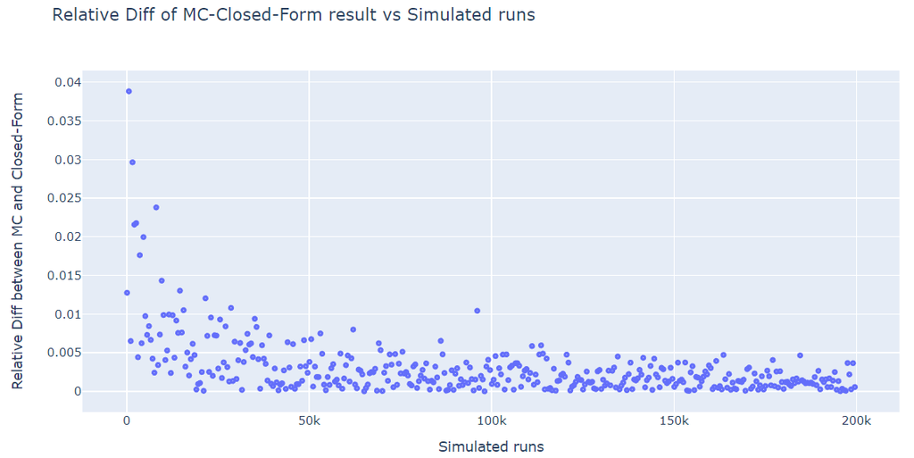

Observation 3(ii):

With reference to the chart above, relative difference of <1% is only observable after 100k simulations.

As for the 0.5% relative difference threshold, there were only close contacts to the threshold after midway between 100k-150k simulations. Further testing is definitely required to discover the optimum number of simulation to gain assurance that the relative differences will consistently remain beneath the 0.5% threshold.

No additional simulations were conducted out of consideration for practicality and performance.

Question 3(iii):

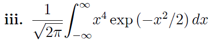

Derivation for Exact Solution:

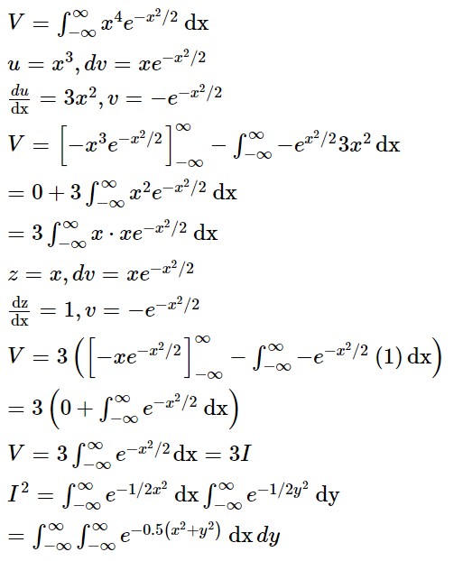

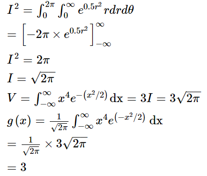

Calculation used in MC Integral

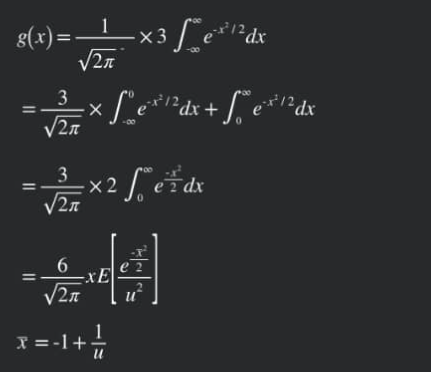

```python
#Question 3(iii)

#Gaussian Integral
Exct3iii = 3 # derivation show above

scalar3 =  6/sqrt(2*np.pi)

sim_runs3=[]; sim_result3=[];closed_form3 =[]; price_diff3=[]

for i in range(len(runs)):
    randsetiii = pd.DataFrame(random.rand(runs[i]))

    # (-1+1/U)**2
    nu_xiii = -1+(1/randsetiii)

    #I= g(nu_x)/(U*U)
    g3iii= np.exp(-(nu_xiii*nu_xiii)/2)

    full3= g3iii/(randsetiii*randsetiii)


    # Expected [ g(nu_x)/(U*U)]
    I3iii =  scalar3*average(full3)

    # Modulus of Relative Difference
    diff3 = np.absolute(I3iii/Exct3iii-1)

    #Appending data into list
    sim_runs3.append(runs[i])
    closed_form3.append(Exct3iii)
    sim_result3.append(I3iii)
    price_diff3.append(diff3)

Agg_df3 = pd.DataFrame({
    'Simulated runs':sim_runs3, 'Closed-Form Solution': closed_form3,
    'Simulated result': sim_result3, 'Relative Diff between MC and Closed-Form': price_diff3})
```

```python
fig3 = plotx.scatter(
    Agg_df3, x='Simulated runs', y='Relative Diff between MC and Closed-Form',
    title="Abs Relative Diff of MC-Closed-Form result vs Simulated runs"
     ).update_traces(mode='markers', marker=dict(symbol='circle-dot'))
fig3.update_layout(yaxis_range=[-0.001,0.03])
fig3.show()
```

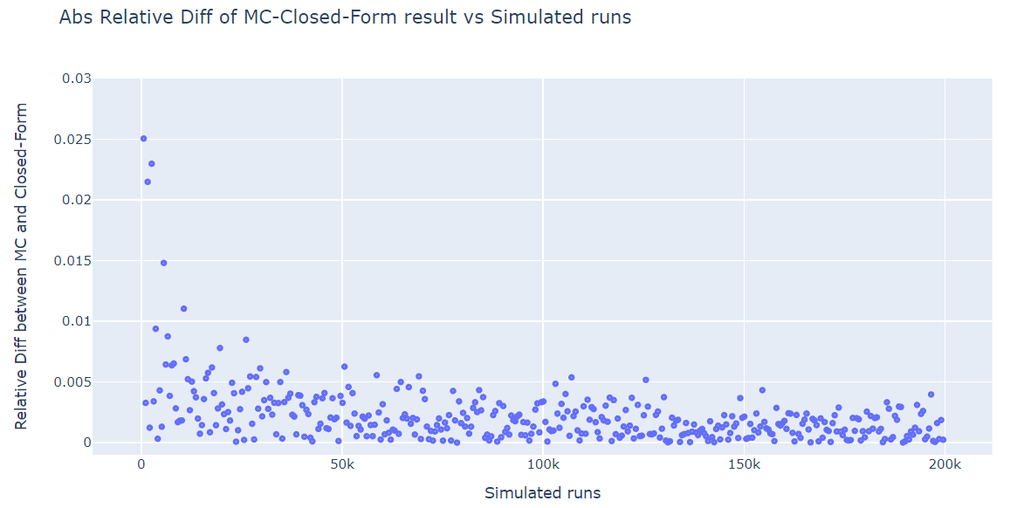

Observation 3(iii):

With reference to the chart above,relative difference of <1% can be observed, roughly after midway between 0-50k simulations.

Relative differences circa 0.5% can still be observed after 100k simulation.Further testing is definitely required, in order to discover the optimum number of simulation to gain assurance that the relative differences will consistently remain beneath the 0.5% threshold.

No additional simulations were conducted out of consideration for practicality and performance.

Conclusion: Based on the observation above, 100k runs of random simulation should be sufficient to run Monte Carlo Integration, barring a relative threshold of 1% (to the exact solution) and the user is indifferent towards the small difference in performance runtime.

References: Ahmad, Riaz (2023). Tutorials- Further Numerical Methods & FDM. Retrieved from CQF Learning Portal: https://learn.cqf.com/courses/170/modules/items/2647